# Lab-8

## Multiple categorical variables

### Create age group

Here, we create an `age_group` categorical variable. If a professor is in 30-39, then we code `age_group` as 1; If 40-49, we code `age_group` as 2, If 50-59, we code `age_group` as 3; If 60 and above, then 4

```r
tr1 <- tr1 %>%
  mutate(age_group  = if_else(age <40 ,1 ,
                      if_else(age <50 ,2,
                      if_else(age <60 ,3, 4))) %>% as.factor())
```

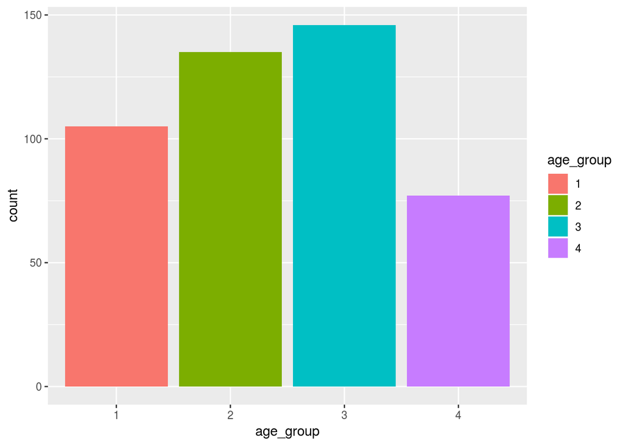

```r
ggplot(tr1, aes(x = age_group, fill = age_group )) +
  geom_bar()
```

```r
m_cat <- lm(eval ~ age_group + beauty, tr1)
coef(m_cat)
```

```
## (Intercept)  age_group2  age_group3  age_group4      beauty
## 3.945220309 0.075307935 0.094569497 0.007652922 0.137096194
```

### Visualization

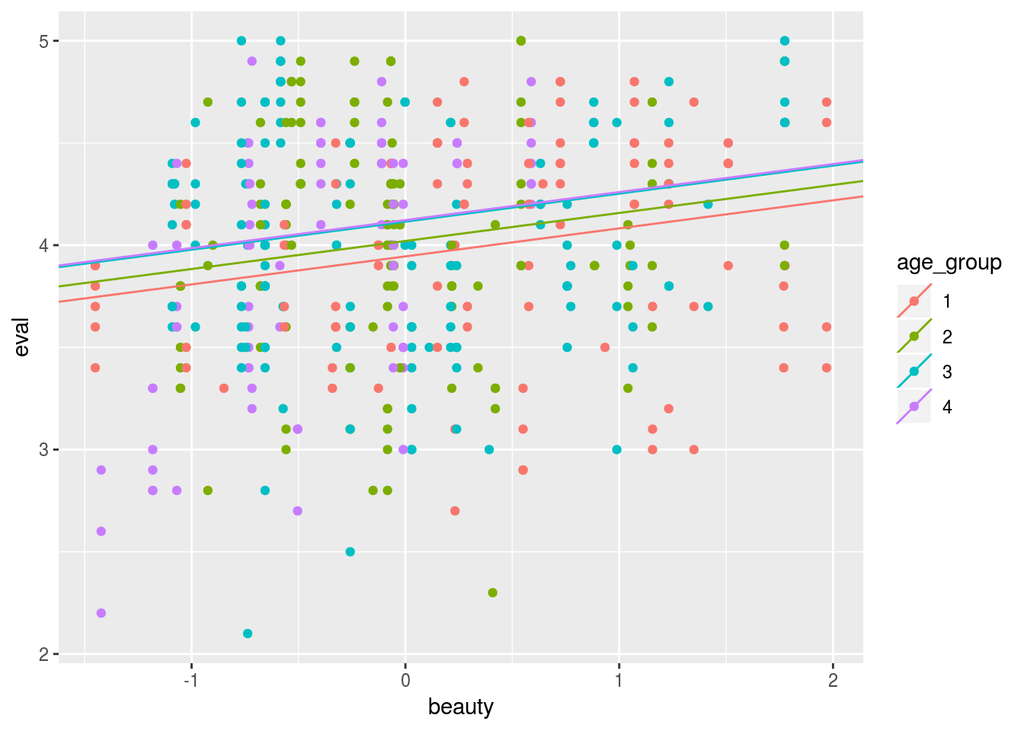

```r
# Calculate race-specific intercepts
intercepts <- c(coef(m_cat)["(Intercept)"],
                coef(m_cat)["(Intercept)"] + coef(m_cat)["age_group2"],
                coef(m_cat)["(Intercept)"] + coef(m_cat)["age_group2"] +
coef(m_cat)["age_group3"],
 coef(m_cat)["(Intercept)"] + coef(m_cat)["age_group2"] +
coef(m_cat)["age_group3"] +coef(m_cat)["age_group4"] )

lines.df <- data.frame(intercepts = intercepts,
                       slopes = rep(coef(m_cat)["beauty"], 4),
                       age_group = levels(tr1$age_group))

qplot(x = beauty, y = eval, color = age_group, data = tr1) +
  geom_abline(aes(intercept = intercepts,
                  slope = slopes, color = age_group), data = lines.df)
```

## Interaction Analysis

### Marginal Effect

Marginal effects tells us how a dependent variable (outcome) changes when a specific independent variable (explanatory variable) changes. Other covariates are assumed to be held constant. Marginal effects are often calculated when analyzing regression analysis results.

For example, we have this model:

$$\hat eval_i = \hat \beta_0 +\hat \beta_1 beauty_i + \hat \beta_2 age + u$$

## Interacting dummy variable with dummy variable

$$\hat{eval_i} = \hat{\beta}_0 + \hat{\beta}_1 female_i + \hat{\beta}_2 tenure_i + \hat{\beta}_3 female_i*tenure_i + u$$

```r
# two equaviliant way of interaction
m_inter1 <- lm(eval ~ gender*tenure ,  tr1)

m_inter2 <- lm(eval ~  gender + tenure + gender:tenure ,  tr1)
```

```r
stargazer(m_inter1,m_inter2, header = F, type = "text")
```

tenureyes -0.406*** -0.406***  
(0.083) (0.083)

genderfemale:tenureyes 0.461*** 0.461***  
(0.121) (0.121)

Constant 4.396*** 4.396***  
(0.074) (0.074)

Observations 463 463  
R2 0.072 0.072  
Adjusted R2 0.066 0.066  
Residual Std. Error (df = 459) 0.536 0.536  
F Statistic (df = 3; 459) 11.823*** 11.823***  
=========================================================== Note: *p<0.1; **p<0.05;*** p<0.01